# 项目：全美枪支数据分析

## 目录

- 简介
- 数据整理
- 探索性数据分析
- 结论

## 简介

> 该数据来自联邦调查局 (FBI) 的全国即时犯罪背景调查系统 (NICS)。NICS 用于确定潜在买家是否有资格购买枪支或爆炸物。枪支店可以进入这个系统，以确保每位客户没有犯罪记录或符合资格购买。该数据已经收纳了来自 census.gov 的州级数据作为补充数据。NICS 数据在一个 xlsx 文件格式的一个表格中，它包含了按照月份 (month)、州 (state) 、类型 (type) 统计的武器调查数量 (the number of firearm checks) ;美国的人口普查数据 (U.S. census data) 储存在一个 csv 文件中。它包含了州级的几个变量，每个州的大多数变量在 2016 年只有一个数据点，但一些变量有一年以上的数据。 通过以上数据，我们将提出以下问题:
> 1. 各个州的枪支拥有数量
> 2. 各个州的人均拥有枪支的数量
> 3. 各个州的合法枪支的比例
> 4. 各个州白人比例于合法枪支比例的关系
> 5. 各个州人口增加率和武器增长率的关系(2011-2016)

```python
# 用这个框对你计划使用的所有数据包进行设置
#   导入语句。
import pandas as pd
import numpy as np
import matplotlib.pyplot as plt

%matplotlib inline
```

## 数据整理

> 读取`gun_data.xlsx`枪支持有数据 以及`U.S. Census Data.csv` 人口数据。分析并且清理数据

### 数据读取

```python
# 加载数据并打印几行。进行这几项操作，来检查数据
#   类型，以及是否有缺失数据或错误数据的情况。
df_gun = pd.read_excel('gun_data.xlsx')
df_census = pd.read_csv('U.S. Census Data.csv')
```

### 数据分析

```python
#分析枪支持有数据
df_gun.info()
```

```
<class 'pandas.core.frame.DataFrame'>
RangeIndex: 12485 entries, 0 to 12484
Data columns (total 27 columns):
month                        12485 non-null object
state                        12485 non-null object
permit                       12461 non-null float64
permit_recheck               1100 non-null float64
handgun                      12465 non-null float64
long_gun                     12466 non-null float64
other                        5500 non-null float64
multiple                     12485 non-null int64
admin                        12462 non-null float64
prepawn_handgun              10542 non-null float64
prepawn_long_gun             10540 non-null float64
prepawn_other                5115 non-null float64
redemption_handgun           10545 non-null float64
redemption_long_gun          10544 non-null float64
redemption_other             5115 non-null float64
returned_handgun             2200 non-null float64
returned_long_gun            2145 non-null float64
returned_other               1815 non-null float64
rentals_handgun              990 non-null float64
rentals_long_gun             825 non-null float64
private_sale_handgun         2750 non-null float64
private_sale_long_gun        2750 non-null float64
private_sale_other           2750 non-null float64
return_to_seller_handgun     2475 non-null float64
return_to_seller_long_gun    2750 non-null float64
return_to_seller_other       2255 non-null float64
totals                       12485 non-null int64
dtypes: float64(23), int64(2), object(2)
memory usage: 2.6+ MB
```

### 数据清理

> 填充枪支数据中缺失的数据

```python
df_gun.fillna(0, inplace=True)

df_gun.info()
```

```
<class 'pandas.core.frame.DataFrame'>
RangeIndex: 12485 entries, 0 to 12484
Data columns (total 27 columns):
month                        12485 non-null object
state                        12485 non-null object
permit                       12485 non-null float64
permit_recheck               12485 non-null float64
handgun                      12485 non-null float64
long_gun                     12485 non-null float64
other                        12485 non-null float64
multiple                     12485 non-null int64
admin                        12485 non-null float64
prepawn_handgun              12485 non-null float64
prepawn_long_gun             12485 non-null float64
prepawn_other                12485 non-null float64
redemption_handgun           12485 non-null float64
redemption_long_gun          12485 non-null float64
redemption_other             12485 non-null float64
returned_handgun             12485 non-null float64
returned_long_gun            12485 non-null float64
returned_other               12485 non-null float64
rentals_handgun              12485 non-null float64
rentals_long_gun             12485 non-null float64
private_sale_handgun         12485 non-null float64
private_sale_long_gun        12485 non-null float64
private_sale_other           12485 non-null float64
return_to_seller_handgun     12485 non-null float64
return_to_seller_long_gun    12485 non-null float64
return_to_seller_other       12485 non-null float64
totals                       12485 non-null int64
dtypes: float64(23), int64(2), object(2)
memory usage: 2.6+ MB
```

> 查看是否有重复数据

```python
df_gun[df_gun.duplicated(['month', 'state']) == True].shape
```

```
(0, 27)
```

> 没有重复数据，无需去重

> 查看所有州的条目数

```python
df_gun['state'].value_counts()
```

```
Missouri                227
Mariana Islands         227
Indiana                 227
Pennsylvania            227
Michigan                227
Arizona                 227
Maryland                227
Florida                 227
Arkansas                227
Virginia                227
Wyoming                 227
Tennessee               227
Oklahoma                227
Puerto Rico             227
Colorado                227
Connecticut             227
West Virginia           227
Utah                    227
South Carolina          227
New Jersey              227
Vermont                 227
New Mexico              227
Texas                   227
South Dakota            227
District of Columbia    227
Hawaii                  227
Massachusetts           227
Oregon                  227
Washington              227
Louisiana               227
New Hampshire           227
Wisconsin               227
Kentucky                227
Iowa                    227
Nevada                  227
Rhode Island            227
Delaware                227
Virgin Islands          227
North Dakota            227
Alabama                 227
Montana                 227
Georgia                 227
Alaska                  227
Kansas                  227
Ohio                    227
Illinois                227
Idaho                   227
Mississippi             227
Minnesota               227
Nebraska                227
North Carolina          227
Guam                    227
California              227
New York                227
Maine                   227
Name: state, dtype: int64
```

### 分析人口数据集

```python
df_census.info()
```

```
<class 'pandas.core.frame.DataFrame'>
RangeIndex: 85 entries, 0 to 84
Data columns (total 52 columns):
Fact              80 non-null object
Fact Note         28 non-null object
Alabama           65 non-null object
Alaska            65 non-null object
Arizona           65 non-null object
Arkansas          65 non-null object
California        65 non-null object
Colorado          65 non-null object
Connecticut       65 non-null object
Delaware          65 non-null object
Florida           65 non-null object
Georgia           65 non-null object
Hawaii            65 non-null object
Idaho             65 non-null object
Illinois          65 non-null object
Indiana           65 non-null object
Iowa              65 non-null object
Kansas            65 non-null object
Kentucky          65 non-null object
Louisiana         65 non-null object
Maine             65 non-null object
Maryland          65 non-null object
Massachusetts     65 non-null object
Michigan          65 non-null object
Minnesota         65 non-null object
Mississippi       65 non-null object
Missouri          65 non-null object
Montana           65 non-null object
Nebraska          65 non-null object
Nevada            65 non-null object
New Hampshire     65 non-null object
New Jersey        65 non-null object
New Mexico        65 non-null object
New York          65 non-null object
North Carolina    65 non-null object
North Dakota      65 non-null object
Ohio              65 non-null object
Oklahoma          65 non-null object
Oregon            65 non-null object
Pennsylvania      65 non-null object
Rhode Island      65 non-null object
South Carolina    65 non-null object
South Dakota      65 non-null object
Tennessee         65 non-null object
Texas             65 non-null object
Utah              65 non-null object
Vermont           65 non-null object
Virginia          65 non-null object
Washington        65 non-null object
West Virginia     65 non-null object
Wisconsin         65 non-null object
Wyoming           65 non-null object
dtypes: object(52)
memory usage: 34.6+ KB
```

> 通过信息，可以知道。大多数数据只有65行。而整个表格是85行。通过查看表格可以知道，65行之后只是一些统计的无效数据。所以需要删除无效数据

```python
df_census.drop('Fact Note', axis=1, inplace=True)
df_census.drop(np.arange(64,85), inplace=True)
df_census.info()
```

```
<class 'pandas.core.frame.DataFrame'>
Int64Index: 64 entries, 0 to 63
Data columns (total 51 columns):
Fact              64 non-null object
Alabama           64 non-null object
Alaska            64 non-null object
Arizona           64 non-null object
Arkansas          64 non-null object
California        64 non-null object
Colorado          64 non-null object
Connecticut       64 non-null object
Delaware          64 non-null object
Florida           64 non-null object
Georgia           64 non-null object
Hawaii            64 non-null object
Idaho             64 non-null object
Illinois          64 non-null object
Indiana           64 non-null object
Iowa              64 non-null object
Kansas            64 non-null object
Kentucky          64 non-null object
Louisiana         64 non-null object
Maine             64 non-null object
Maryland          64 non-null object
Massachusetts     64 non-null object
Michigan          64 non-null object
Minnesota         64 non-null object
Mississippi       64 non-null object
Missouri          64 non-null object
Montana           64 non-null object
Nebraska          64 non-null object
Nevada            64 non-null object
New Hampshire     64 non-null object
New Jersey        64 non-null object
New Mexico        64 non-null object
New York          64 non-null object
North Carolina    64 non-null object
North Dakota      64 non-null object
Ohio              64 non-null object
Oklahoma          64 non-null object
Oregon            64 non-null object
Pennsylvania      64 non-null object
Rhode Island      64 non-null object
South Carolina    64 non-null object
South Dakota      64 non-null object
Tennessee         64 non-null object
Texas             64 non-null object
Utah              64 non-null object
Vermont           64 non-null object
Virginia          64 non-null object
Washington        64 non-null object
West Virginia     64 non-null object
Wisconsin         64 non-null object
Wyoming           64 non-null object
dtypes: object(51)
memory usage: 26.0+ KB
```

> 我们通过时间来匹配对应的数据，在人口表中。比较齐全的是2016年的数据，所以我们以2016的数据作为统计的依据。

```python
df_census_2016 = df_census[df_census.Fact.str.contains('2016')].set_index('Fact')
df_census_2016 = df_census_2016.transpose()
df_gun_2016 = df_gun[df_gun['month'].str.contains('2016')].groupby('state').mean()
df_census_2016.head()
```

| Fact | Population estimates, July 1, 2016, (V2016) | Population estimates base, April 1, 2010, (V2016) | Population, percent change - April 1, 2010 (estimates base) to July 1, 2016, (V2016) | Persons under 5 years, percent, July 1, 2016, (V2016) | Persons under 18 years, percent, July 1, 2016, (V2016) | Persons 65 years and over, percent, July 1, 2016, (V2016) | Female persons, percent, July 1, 2016, (V2016) | White alone, percent, July 1, 2016, (V2016) | Black or African American alone, percent, July 1, 2016, (V2016) | American Indian and Alaska Native alone, percent, July 1, 2016, (V2016) | Asian alone, percent, July 1, 2016, (V2016) | Native Hawaiian and Other Pacific Islander alone, percent, July 1, 2016, (V2016) | Two or More Races, percent, July 1, 2016, (V2016) | Hispanic or Latino, percent, July 1, 2016, (V2016) | White alone, not Hispanic or Latino, percent, July 1, 2016, (V2016) | Housing units, July 1, 2016, (V2016) | Building permits, 2016 |
| --- | --- | --- | --- | --- | --- | --- | --- | --- | --- | --- | --- | --- | --- | --- | --- | --- | --- |
| Alabama | 4,863,300 | 4,780,131 | 1.70% | 6.00% | 22.60% | 16.10% | 51.60% | 69.30% | 26.80% | 0.70% | 1.40% | 0.10% | 1.60% | 4.20% | 65.80% | 2,230,185 | 15,001 |
| Alaska | 741,894 | 710,249 | 4.50% | 7.30% | 25.20% | 10.40% | 47.70% | 66.10% | 3.80% | 15.20% | 6.30% | 1.30% | 7.30% | 7.00% | 61.20% | 310,658 | 1,503 |
| Arizona | 6,931,071 | 6,392,301 | 8.40% | 6.30% | 23.50% | 16.90% | 50.30% | 83.30% | 4.90% | 5.40% | 3.40% | 0.30% | 2.80% | 30.90% | 55.50% | 2,961,003 | 35,578 |
| Arkansas | 2,988,248 | 2,916,025 | 2.50% | 6.40% | 23.60% | 16.30% | 50.90% | 79.40% | 15.70% | 1.00% | 1.60% | 0.30% | 2.00% | 7.30% | 72.90% | 1,354,762 | 9,474 |
| California | 39,250,017 | 37,254,522 | 5.40% | 6.30% | 23.20% | 13.60% | 50.30% | 72.70% | 6.50% | 1.70% | 14.80% | 0.50% | 3.80% | 38.90% | 37.70% | 14,060,525 | 102,350 |

> 通过输出人口表的数据，我们发现数据包含一些特殊符号。如逗号和百分号。我们需要把这些字段转化成float

```python
# df_census_2016.info()
df_census_2016.replace({',': ''}, regex=True, inplace=True) # 处理带逗号的数值，去掉逗号
df_census_2016.replace({'Z': 0}, inplace=True) #将数据中的 Z 替换为 0
df_census_2016 = df_census_2016.applymap(lambda x: float(x[:-2])/100 if str(x)[-1]=='%' else x) #转换带 % 的数据
df_census_2016 = df_census_2016.applymap(lambda x: str(x)[1:] if str(x)[0]=='$' else x) #转换带 $ 的数据
df_census_2016 = df_census_2016.apply(pd.to_numeric, errors='coerce') # 将数据集的列转换为数字格式

df_census_2016.head()
```

| Fact | Population estimates, July 1, 2016, (V2016) | Population estimates base, April 1, 2010, (V2016) | Population, percent change - April 1, 2010 (estimates base) to July 1, 2016, (V2016) | Persons under 5 years, percent, July 1, 2016, (V2016) | Persons under 18 years, percent, July 1, 2016, (V2016) | Persons 65 years and over, percent, July 1, 2016, (V2016) | Female persons, percent, July 1, 2016, (V2016) | White alone, percent, July 1, 2016, (V2016) | Black or African American alone, percent, July 1, 2016, (V2016) | American Indian and Alaska Native alone, percent, July 1, 2016, (V2016) | Asian alone, percent, July 1, 2016, (V2016) | Native Hawaiian and Other Pacific Islander alone, percent, July 1, 2016, (V2016) | Two or More Races, percent, July 1, 2016, (V2016) | Hispanic or Latino, percent, July 1, 2016, (V2016) | White alone, not Hispanic or Latino, percent, July 1, 2016, (V2016) | Housing units, July 1, 2016, (V2016) | Building permits, 2016 |
| --- | --- | --- | --- | --- | --- | --- | --- | --- | --- | --- | --- | --- | --- | --- | --- | --- | --- |
| Alabama | 4863300 | 4780131 | 0.017 | 0.060 | 0.226 | 0.161 | 0.516 | 0.693 | 0.268 | 0.007 | 0.014 | 0.001 | 0.016 | 0.042 | 0.658 | 2230185 | 15001 |
| Alaska | 741894 | 710249 | 0.045 | 0.073 | 0.252 | 0.104 | 0.477 | 0.661 | 0.038 | 0.152 | 0.063 | 0.013 | 0.073 | 0.070 | 0.612 | 310658 | 1503 |
| Arizona | 6931071 | 6392301 | 0.084 | 0.063 | 0.235 | 0.169 | 0.503 | 0.833 | 0.049 | 0.054 | 0.034 | 0.003 | 0.028 | 0.309 | 0.555 | 2961003 | 35578 |
| Arkansas | 2988248 | 2916025 | 0.025 | 0.064 | 0.236 | 0.163 | 0.509 | 0.794 | 0.157 | 0.010 | 0.016 | 0.003 | 0.020 | 0.073 | 0.729 | 1354762 | 9474 |
| California | 39250017 | 37254522 | 0.054 | 0.063 | 0.232 | 0.136 | 0.503 | 0.727 | 0.065 | 0.017 | 0.148 | 0.005 | 0.038 | 0.389 | 0.377 | 14060525 | 102350 |

> 判断是否有重复州的数据

```python
df_census_2016[df_census_2016.duplicated() == True].shape
```

```
(0, 17)
```

> 无重复数据需要处理 接下来 要合并枪支数据和人口数据

```python
df_2016 = df_gun_2016.join(df_census_2016)
df_2016.head()
```

| state | permit | permit_recheck | handgun | long_gun | other | multiple | admin | prepawn_handgun | prepawn_long_gun | prepawn_other | ... | White alone, percent, July 1, 2016, (V2016) | Black or African American alone, percent, July 1, 2016, (V2016) | American Indian and Alaska Native alone, percent, July 1, 2016, (V2016) | Asian alone, percent, July 1, 2016, (V2016) | Native Hawaiian and Other Pacific Islander alone, percent, July 1, 2016, (V2016) | Two or More Races, percent, July 1, 2016, (V2016) | Hispanic or Latino, percent, July 1, 2016, (V2016) | White alone, not Hispanic or Latino, percent, July 1, 2016, (V2016) | Housing units, July 1, 2016, (V2016) | Building permits, 2016 |
| --- | --- | --- | --- | --- | --- | --- | --- | --- | --- | --- | --- | --- | --- | --- | --- | --- | --- | --- | --- | --- | --- |
| Alabama | 24253.250000 | 0.000000 | 12760.250000 | 10163.583333 | 508.666667 | 545.416667 | 0.416667 | 9.250000 | 9.500000 | 0.166667 | ... | 0.693 | 0.268 | 0.007 | 0.014 | 0.001 | 0.016 | 0.042 | 0.658 | 2.23018e+06 | 15001 |
| Alaska | 260.083333 | 0.000000 | 3124.250000 | 3073.916667 | 240.750000 | 193.000000 | 0.000000 | 7.000000 | 5.833333 | 0.000000 | ... | 0.661 | 0.038 | 0.152 | 0.063 | 0.013 | 0.073 | 0.07 | 0.612 | 310658 | 1503 |
| Arizona | 7314.250000 | 425.750000 | 13898.666667 | 9082.333333 | 1093.500000 | 659.000000 | 0.000000 | 6.166667 | 5.000000 | 0.250000 | ... | 0.833 | 0.049 | 0.054 | 0.034 | 0.003 | 0.028 | 0.309 | 0.555 | 2.961e+06 | 35578 |
| Arkansas | 4621.333333 | 586.333333 | 6687.000000 | 6843.333333 | 254.916667 | 366.666667 | 11.916667 | 6.416667 | 9.666667 | 0.250000 | ... | 0.794 | 0.157 | 0.01 | 0.016 | 0.003 | 0.02 | 0.073 | 0.729 | 1.35476e+06 | 9474 |
| California | 86415.083333 | 0.000000 | 46696.250000 | 46212.500000 | 17642.250000 | 0.000000 | 0.000000 | 0.000000 | 0.000000 | 0.000000 | ... | 0.727 | 0.065 | 0.017 | 0.148 | 0.005 | 0.038 | 0.389 | 0.377 | 1.40605e+07 | 102350 |

5 rows × 42 columns

## 探索性数据分析

> 到这里，基本的数据清理工作就完成了。得到一张2016年的枪支和人口之间的关系表。通过这张表，可以做出以下分析。

### 研究问题1：每个州的武器持有数量对比

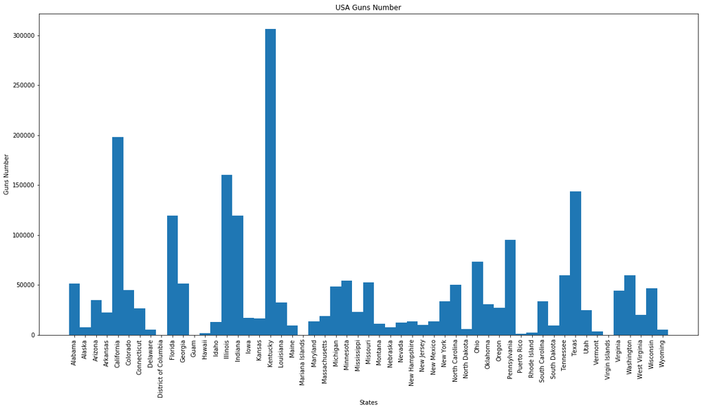

```python
width = 1
plt.figure(figsize=(20,10))
plt.bar(df_2016.index, df_2016['totals'], width)
plt.title("USA Guns Number")
plt.xlabel("States")
plt.ylabel("Guns Number")
plt.xticks(rotation = 90);
```

### 以上图表是当前每个州的枪支持有的数量对比，我们可以看到kentuchy和California的持枪总量比较高

> 研究 每个州的持枪率

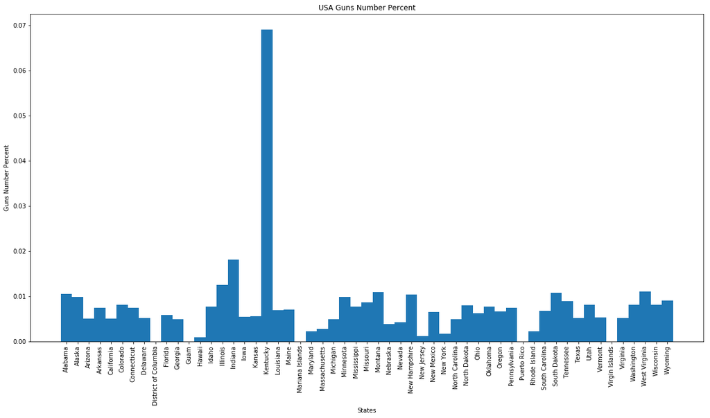

```python
df_2016['Population estimates, July 1, 2016,  (V2016)'] = df_2016['Population estimates, July 1, 2016,  (V2016)'].astype(float)
width = 1
plt.figure(figsize=(20,10))
plt.bar(df_2016.index, df_2016['totals']/df_2016['Population estimates, July 1, 2016,  (V2016)'], width)
plt.title("USA Guns Number Percent")
plt.xlabel("States")
plt.ylabel("Guns Number Percent")
plt.xticks(rotation = 90);
```

### 以上图表是表示每个州的人均持枪的数量，其中kentuchy一枝独秀。人均持枪数接近0.07

> 研究 每个周的合法枪支的比率

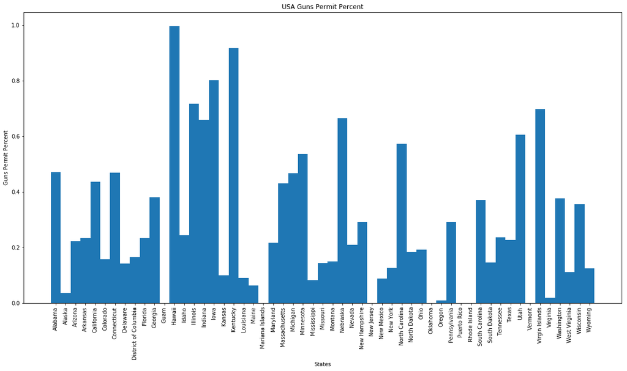

```python
df_2016['Population estimates, July 1, 2016,  (V2016)'] = df_2016['Population estimates, July 1, 2016,  (V2016)'].astype(float)
width = 1
plt.figure(figsize=(20,10))
plt.bar(df_2016.index, (df_2016['permit'] + df_2016['permit_recheck'])/df_2016['totals'], width)
plt.title("USA Guns Permit Percent")
plt.xlabel("States")
plt.ylabel("Guns Permit Percent")
plt.xticks(rotation = 90);
```

### 以上图标显示每个州的合法持枪的比较。其中Hawaii合法枪支比例最高。接近100%

### 研究问题 2：白人比例和合法枪支比率的关系

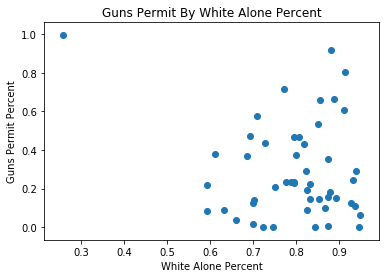

```python
plt.scatter(df_2016['White alone, percent, July 1, 2016,  (V2016)'],(df_2016['permit'] + df_2016['permit_recheck'])/df_2016['totals'])
plt.title("Guns Permit By White Alone Percent")
plt.xlabel("White Alone Percent")
plt.ylabel("Guns Permit Percent")
```

### 当前白人的比例和合法枪支比例的关系，通过图表可以知道。并没有非常明显的线性关系。

> 2011 到 2016年的武器增长率

```python
# 2011 年的枪支数量的平均值
df_gun_2011= df_gun[df_gun['month'].str.contains('2011')].groupby('state').mean()
df_gun_2011.head()
```

| state | permit | permit_recheck | handgun | long_gun | other | multiple | admin | prepawn_handgun | prepawn_long_gun | prepawn_other | ... | returned_other | rentals_handgun | rentals_long_gun | private_sale_handgun | private_sale_long_gun | private_sale_other | return_to_seller_handgun | return_to_seller_long_gun | return_to_seller_other | totals |
| --- | --- | --- | --- | --- | --- | --- | --- | --- | --- | --- | --- | --- | --- | --- | --- | --- | --- | --- | --- | --- | --- |
| Alabama | 419.666667 | 0.0 | 10874.166667 | 12190.833333 | 176.750000 | 521.833333 | 0.000000 | 10.916667 | 15.750000 | 0.000000 | ... | 0.0 | 0.0 | 0.0 | 0.0 | 0.0 | 0.0 | 0.0 | 0.0 | 0.0 | 28008.500000 |
| Alaska | 0.000000 | 0.0 | 2357.583333 | 2883.916667 | 79.583333 | 139.833333 | 0.000000 | 6.166667 | 6.916667 | 0.000000 | ... | 0.0 | 0.0 | 0.0 | 0.0 | 0.0 | 0.0 | 0.0 | 0.0 | 0.0 | 5849.833333 |
| Arizona | 2742.166667 | 0.0 | 9020.416667 | 6773.750000 | 259.250000 | 391.666667 | 0.000000 | 7.916667 | 3.500000 | 0.083333 | ... | 0.0 | 0.0 | 0.0 | 0.0 | 0.0 | 0.0 | 0.0 | 0.0 | 0.0 | 20956.416667 |
| Arkansas | 2507.250000 | 0.0 | 4554.916667 | 6567.166667 | 64.000000 | 306.000000 | 116.916667 | 6.250000 | 22.416667 | 0.000000 | ... | 0.0 | 0.0 | 0.0 | 0.0 | 0.0 | 0.0 | 0.0 | 0.0 | 0.0 | 17185.666667 |
| California | 23218.750000 | 0.0 | 25264.083333 | 26749.000000 | 15.500000 | 0.000000 | 2.000000 | 0.000000 | 0.000000 | 0.000000 | ... | 0.0 | 0.0 | 0.0 | 0.0 | 0.0 | 0.0 | 0.0 | 0.0 | 0.0 | 75475.083333 |

5 rows × 25 columns

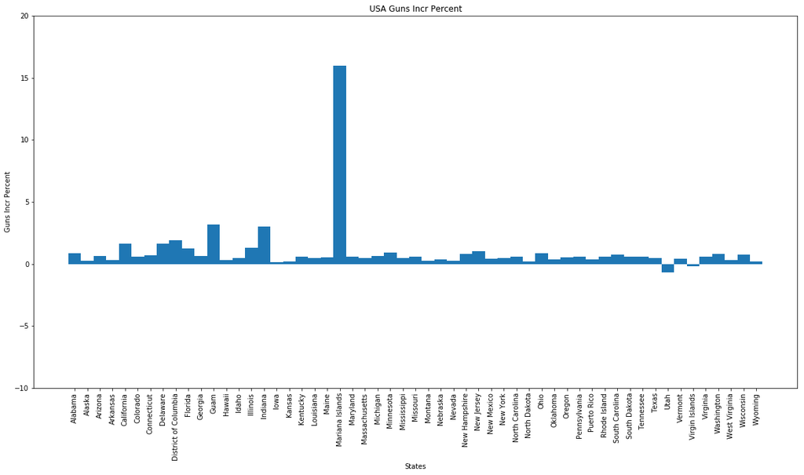

```python
width = 1
plt.figure(figsize=(20,10))
plt.bar(df_gun_2016.index, (df_gun_2016['totals'] - df_gun_2011['totals'])/df_gun_2011['totals'], width)
plt.title("USA Guns Incr Percent")
plt.xlabel("States")
plt.ylabel("Guns Incr Percent")
plt.ylim(-10, 20)

plt.xticks(rotation = 90);
```

### 当前每个州2011-2016武器的增长率。当前Mariana Islands 增长率最高。但是通过表格数据，发现枪支数较低。参考意义不大。

> 人口增长率和武器增长率之间的关系

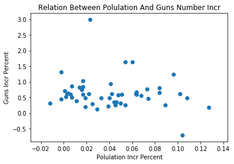

```python
plt.scatter(df_2016['Population, percent change - April 1, 2010 (estimates base) to July 1, 2016,  (V2016)'],(df_gun_2016['totals'] - df_gun_2011['totals'])/df_gun_2011['totals'])
plt.title("Relation Between Polulation And Guns Number Incr")
plt.xlabel("Polulation Incr Percent")
plt.ylabel("Guns Incr Percent")
```

### 武器增长率和人口增长率的关系。通过图表可以看出，武器增长率比较稳定。和人口增加率没有直接的正向关系。

## 结论

> 通过以上数据分析图表，得出以下结论。
> 1. Kentucky 人均持枪数最高。
> 2. 2011到2016 Mariana Islands 增加率最高，但是由于基数太低，无参考意义。
> 3. Hawaii 武器的合法率最高。
> 4. 人口增加和武器增长，并没有直接的线性关系。

### 不足

> 实际上，当前的数据是以2016年为标准，样本数量不足。判断比较武断。 而且通过查看表格可以看到，有些武器数据出现的异常数量，会影响数据的准确性。 当前对于数据的分析大多是基于人口数量做出的评定。没有对人口构成，房屋拥有情况进行分析。存在限制。